# Final Project - Intro to Data Science - 6101

We-R-4(3)

2022-04-20

```r
credit1 <- read_csv('application_record.csv')
credit2 <- read_csv('credit_record.csv')
```

# 1 Preparation, Initial Analysis, and Data Tidying:

The data set originally consists of 2 separate csv files that are connected to each other via the ‘ID’ column. The first csv file, application record.csv, consists of personal and socio-economic data that is related to an applicant and can help a bank decide whether to issue them a credit card or not. The second csv file, credit_record.csv, consists of past credit card usage behavior of an applicant. It consists of information such as defaults, payment due dates etc. We will perform a ‘left join’ to merge these two files and so that we are working with the right applicants and will get rid of the extra rows depending on the Null values.

```r
df <- merge(credit1, credit2, by = 'ID', all.x = TRUE)
```

Checking NA values in the updated dataframe and performing cleanup in the dataframe columns.

```r
sum(is.na(df$OCCUPATION_TYPE)) # 'Occupation_type' has nearly 350000 na values in the original dataframe, along with 'Status' and 'months_balance'.
# Removing the NA values from the above columns:
new_df <- na.omit(df, c("STATUS", "MONTHS_BALANCE", "OCCUPATION_TYPE"))
# Making sure the dataframe has distinct values:
df2 <- distinct(new_df, ID, .keep_all = TRUE)
```

The above generated `data frame(df2)` has 25134 rows and 20 variables.

Removing excess columns or ones that do not pertain to the target variable at all.

```r
df2 <- subset( df2, select = -c(FLAG_EMAIL, FLAG_PHONE, FLAG_WORK_PHONE, DAYS_EMPLOYED, DAYS_BIRTH, ID, OCCUPATION_TYPE))
df2$ID <- 1:nrow(df2)
df2 <- df2 %>% relocate(ID, .before = CODE_GENDER)
# Renaming columns to more generic values:
df2 <- df2 %>% rename(gender = CODE_GENDER, owns_car = FLAG_OWN_CAR, owns_realty = FLAG_OWN_REALTY, children = CNT_CHILDREN, total_income = AMT_INCOME_TOTAL, employment_type = NAME_INCOME_TYPE, education_status = NAME_EDUCATION_TYPE, marital_status = NAME_FAMILY_STATUS, housing_type = NAME_HOUSING_TYPE, owns_mobile = FLAG_MOBIL, family_members = CNT_FAM_MEMBERS, months_due = MONTHS_BALANCE, status = STATUS)

df2$months_due <- df2$months_due * (-1)
```

Converting all categorical values to ordinal/numeric values for further computation:

```r
df2$gender <- replace(df2$gender, df2$gender=="M", 1)
df2$gender <- replace(df2$gender, df2$gender=="F", 0)
df2$gender <- as.numeric(df2$gender)

df2$owns_car <- replace(df2$owns_car, df2$owns_car=="Y", 1)
df2$owns_car <- replace(df2$owns_car, df2$owns_car=="N", 0)
df2$owns_car <- as.numeric(df2$owns_car)

df2$owns_realty <- replace(df2$owns_realty, df2$owns_realty=="Y", 1)
df2$owns_realty <- replace(df2$owns_realty, df2$owns_realty=="N", 0)
df2$owns_realty <- as.numeric(df2$owns_realty)

df2$employment_type <- replace(df2$employment_type, df2$employment_type=="Working", 0)
df2$employment_type <- replace(df2$employment_type, df2$employment_type=="Commercial associate", 1)
df2$employment_type <- replace(df2$employment_type, df2$employment_type=="State servant", 2)
df2$employment_type <- replace(df2$employment_type, df2$employment_type=="Student", 3)
df2$employment_type <- replace(df2$employment_type, df2$employment_type=="Pensioner", 4)
df2$employment_type <- as.numeric(df2$employment_type)

df2$education_status <- replace(df2$education_status, df2$education_status=="Secondary / secondary special", 0)
df2$education_status <- replace(df2$education_status, df2$education_status=="Higher education", 1)
df2$education_status <- replace(df2$education_status, df2$education_status=="Incomplete higher", 2)
df2$education_status <- replace(df2$education_status, df2$education_status=="Lower secondary", 3)
df2$education_status <- replace(df2$education_status, df2$education_status=="Academic degree", 4)
df2$education_status <- as.numeric(df2$education_status)

df2$marital_status <- replace(df2$marital_status, df2$marital_status=="Married", 0)
df2$marital_status <- replace(df2$marital_status, df2$marital_status=="Single / not married", 1)
df2$marital_status <- replace(df2$marital_status, df2$marital_status=="Civil marriage", 2)
df2$marital_status <- replace(df2$marital_status, df2$marital_status=="Separated", 3)
df2$marital_status <- replace(df2$marital_status, df2$marital_status=="Widow", 4)
df2$marital_status <- as.numeric(df2$marital_status)

df2$housing_type <- replace(df2$housing_type, df2$housing_type=="House / apartment", 0)
df2$housing_type <- replace(df2$housing_type, df2$housing_type=="Rented apartment", 1)
df2$housing_type <- replace(df2$housing_type, df2$housing_type=="Municipal apartment", 2)
df2$housing_type <- replace(df2$housing_type, df2$housing_type=="With parents", 3)
df2$housing_type <- replace(df2$housing_type, df2$housing_type=="Co-op apartment", 4)
df2$housing_type <- replace(df2$housing_type, df2$housing_type=="Office apartment", 5)
df2$housing_type <- as.numeric(df2$housing_type)

df2$status <- replace(df2$status, df2$status=="0", 0)
df2$status <- replace(df2$status, df2$status=="X", 0)
df2$status <- replace(df2$status, df2$status=="C", 0)
df2$status <- replace(df2$status, df2$status=="1", 0)
df2$status <- replace(df2$status, df2$status=="2", 1)
df2$status <- replace(df2$status, df2$status=="3", 1)
df2$status <- replace(df2$status, df2$status=="4", 1)
df2$status <- replace(df2$status, df2$status=="5", 1)
df2$status <- as.factor(df2$status)
```

## 1.1 Target variable and Data set balancing

The target variable ‘status’ has the following values: 0: 1-29 days past due 1: 30-59 days past due 2: 60-89 days overdue 3: 90-119 days overdue 4: 120-149 days overdue 5: Overdue or bad debts, write-offs for more than 150 days C: paid off that month X: No loan for the month

Any Customers that are overdue for more than 60 days are marked as `risk` or 1 in the target variable. Other customers are marked as 0. The target variable status has a binary outcome, 1 or 0, predicting if an applicant will be a `risk` or `not a risk`.

```r
table(df2$status)
```

We will balance the dataset using a minority oversampling technique called `SMOTE: Synthetic Minority Oversampling Technique`. This technique uses KNN or K-nearest neighbors algorithm to generate synthetic values of the under represented target variable.

```r
library(DMwR)
df2_bal <- SMOTE(status~., df2, perc.over=6000, perc.under=100, k = 5)
table(df2_bal$status)
```

## 1.2 Checking data normality on the df2_bal set

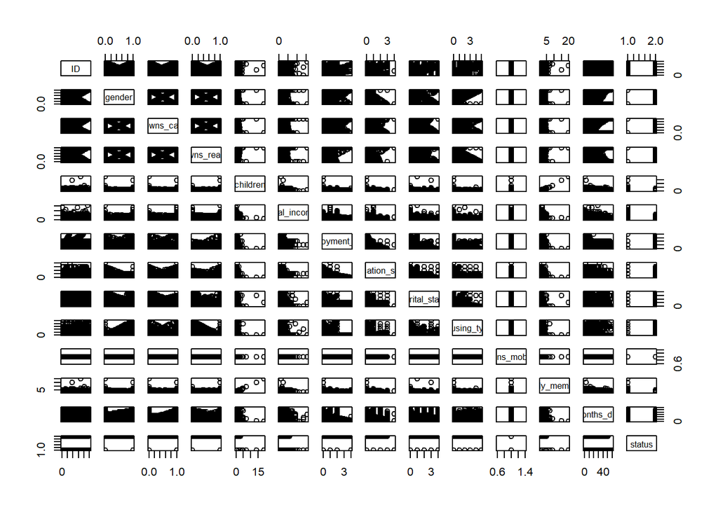

```r
loadPkg("psych")
pairs(df2_bal)
```

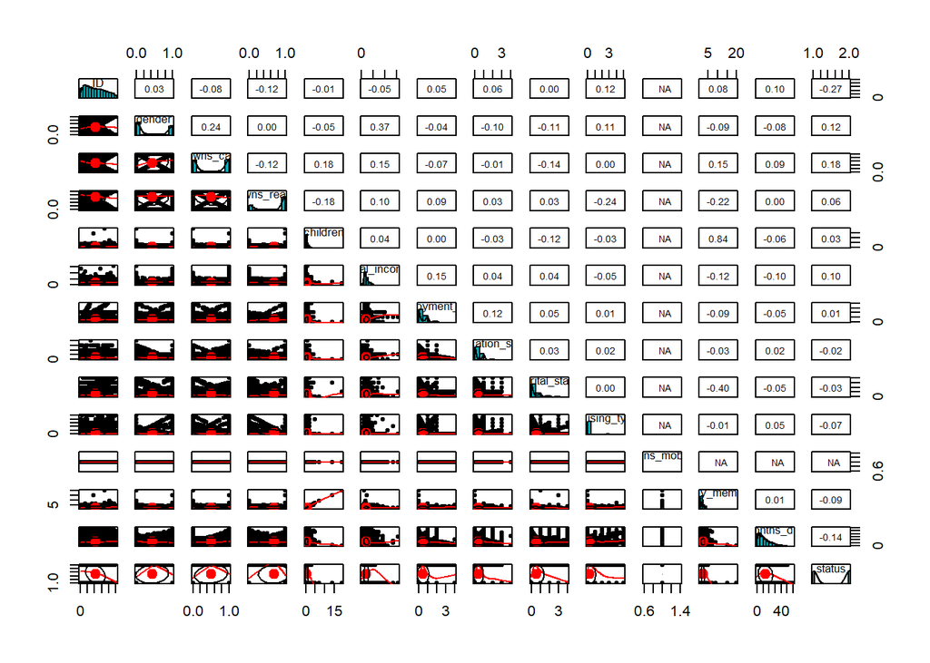

```r
pairs.panels(df2_bal,
             method = "pearson", # correlation method
             hist.col = "#00AFBB", # set histogram color, can use "#22AFBB", "red",
             density = TRUE,  # show density plots
             ellipses = TRUE # show correlation ellipses
             )
```

```r
#unloadPkg(psych)
```

# 2 Chi-squared tests

## 2.1 To test if the data support that applicant’s owned reality much affects status

```r
own_realty_status_table = xtabs(~owns_realty+status, data = df2_bal)
own_realty_status_table
```

```r
chisqres_own_realty = chisq.test(own_realty_status_table)
chisqres_own_realty
```

## 2.2 To test if the data support that applicant’s total income much affects status

```r
totalincome_statustable = xtabs(~total_income + status, data = df2_bal)
totalincome_statustable
```

```r
chisqres_totalincome = chisq.test(totalincome_statustable)
chisqres_totalincome
```

## 2.3 To test if the data support that applicant’s marital status much affects status

```r
maritalstatus_status_table = xtabs(~marital_status+status, data = df2_bal)
maritalstatus_status_table
```

```r
chisqres_maritalstatus = chisq.test(maritalstatus_status_table )
chisqres_maritalstatus
```

## 2.4 To test if the data support that applicant’s education status much affects status

```r
education_status_table = xtabs(~education_status + status, data = df2_bal)
education_status_table
```

```r
chisqres_education = chisq.test(education_status_table)
chisqres_education
```

## 2.5 To test if the data support that applicant’s months_due much affects status

```r
months_due_status_table = xtabs(~months_due + status, data = df2_bal)
months_due_status_table
```

```r
chisqres_monthsBalance = chisq.test(months_due_status_table)
chisqres_monthsBalance
```

# 3 Splitting the balanced set into Train/Test:

Splitting the model into train and test data sets using the ‘caTools’ library:

```r
library(caTools)
split <- sample.split(df2_bal$status, SplitRatio = 0.80)

train <- subset(df2_bal, split == TRUE)
test <- subset(df2_bal, split == FALSE)


## Let's check the count of unique value in the target variable
as.data.frame(table(train$status))
```

# 4 Logit Model 1:

## 4.1 Creating a Logistic regression model with the train dataset:

```r
model <- glm(status~., data = train, family = binomial)
summary(model)
```

## 4.2 Predicting the target values using the generated model against the test data set:

```r
predict_set <- predict(model, test, type = 'response')
```

Now, comparing the original values in the test set with the predicted values:

```r
table(test$status, predict_set > 0.5)
```

Now, calculating the Accuracy, precision and recall of the generated model:

```r
#                         predicted
#                   0                  1
# Actual 0   True Negative  TN      False Positive FP
# Actual 1   False Negative FN      True Positive  TP
#
#
# Accuracy    = (TP + TN) / Total
# Precision   = TP / (TP + FP)
# Recall rate = TP / (TP + FN) = Sensitivity
# Specificity = TN / (TN + FP)
# F1_score is the "harmonic mean" of precision and recall
#          F1 = 2 (precision)(recall)/(precision + recall)
Accuracy = 0.678
Precision = .679
Recall = 0.683
```

## 4.3 Generating the ROC:

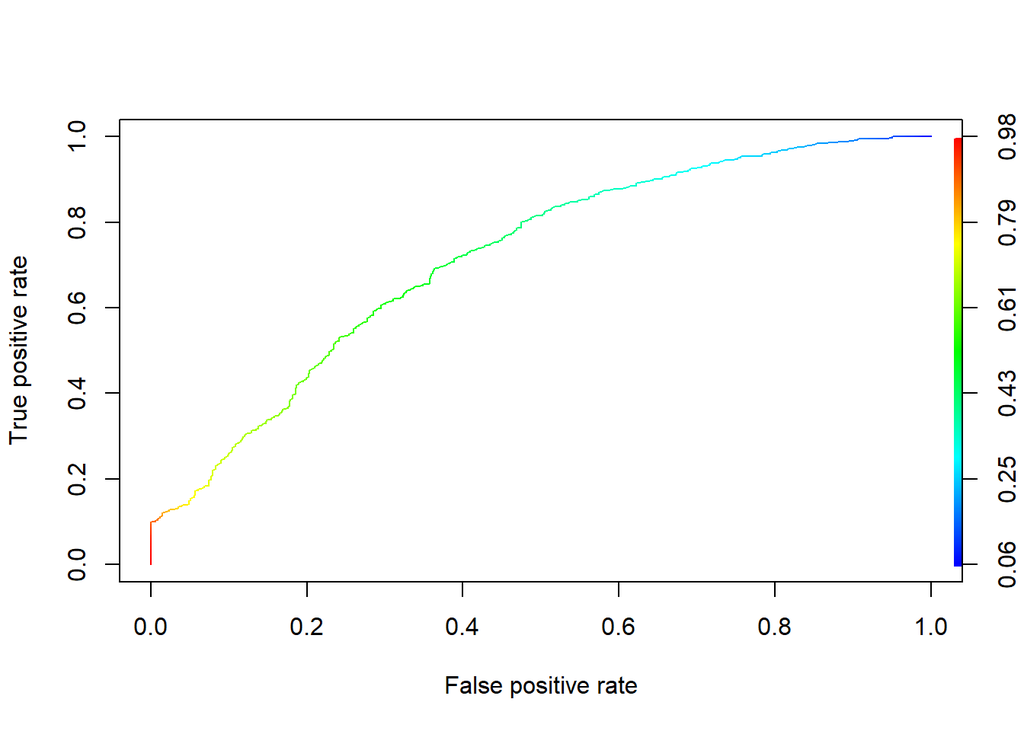

```r
library(pROC)
library(ROCR)
ROCRpred <- prediction(predict_set, test$status)
ROCRperf <- performance(ROCRpred, 'tpr','fpr')
plot(ROCRperf, colorize = TRUE, text.adj = c(-0.2,1.7))
```

```r
ROC_prob = roc(test$status, predict_set, type = "response")
auc(ROC_prob)
```

# 5 Feature Selection:

Now, performing feature selection on the data set to select ideal variables that cause a variation in the target variable:

## 5.1 Performing Exhaustive Search

Model selection by exhaustive (default) search, forward or backward stepwise, or sequential replacement. The plot will essentially show the Adjusted R^2 when using the variables across the bottom

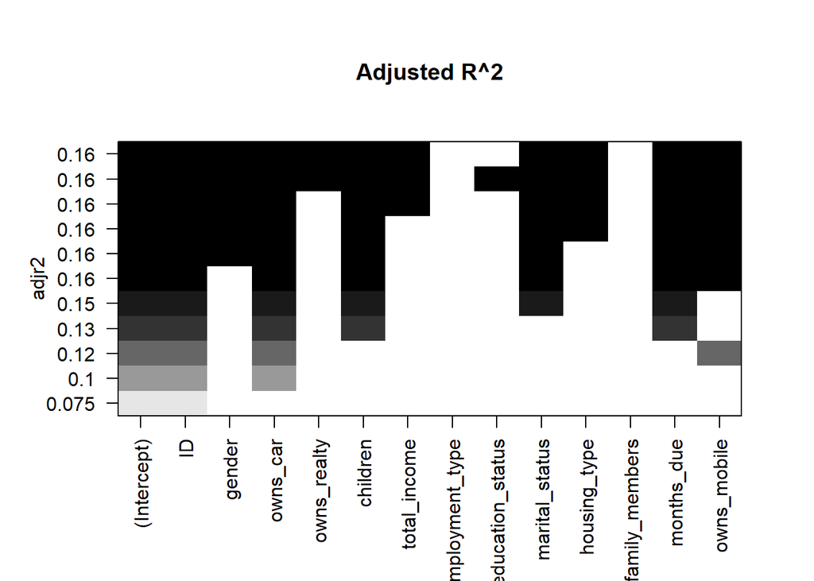

```r
library(ISLR)

loadPkg("leaps")
#This is essentially best fit
reg_best10 <- regsubsets(status~. , data = df2_bal, nvmax = 10, nbest = 1, method = "exhaustive")  # leaps::regsubsets()
plot(reg_best10, scale = "adjr2", main = "Adjusted R^2")
```

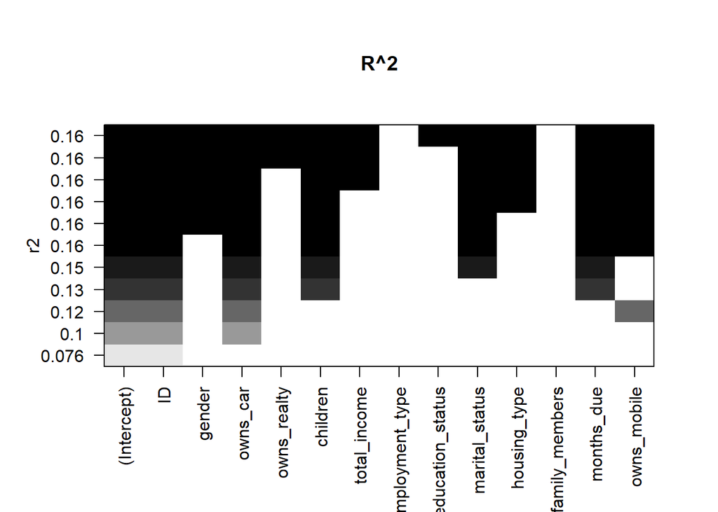

```r
plot(reg_best10, scale = "r2", main = "R^2")
```

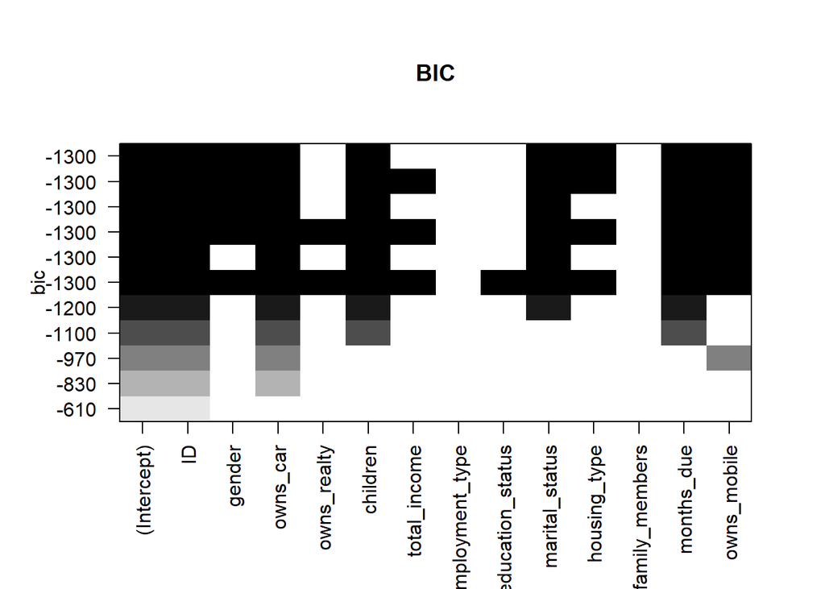

```r
plot(reg_best10, scale = "bic", main = "BIC")
```

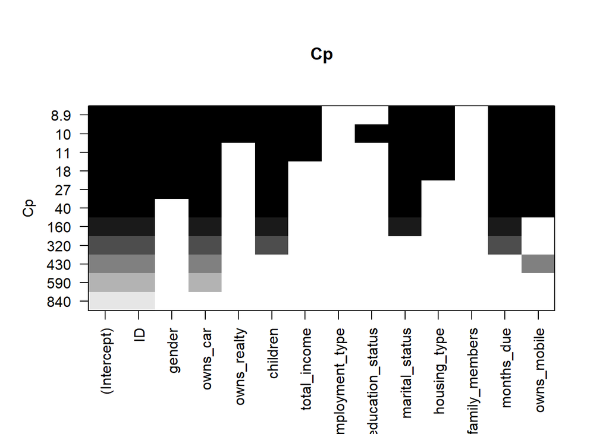

```r
plot(reg_best10, scale = "Cp", main = "Cp")
```

```r
summary(reg_best10)
```

We will go ahead and create a logistic model explaining how these selected variables have an effect on the target variable(status) and will compare the new models accuracy with the earlier model.